# Отчёт по лабораторной работе 8

Настройка сетевых сервисов. DHCP

Седохин Даниил Алексеевич

1132231845@pfur.ru

Российский университет дружбы народов

# 1 Цель работы

Приобретение практических навыков по настройке динамического распределения IP-адресов посредством протокола DHCP (Dynamic Host Configuration Protocol) в локальной сети.

# 2 Задание

В логическую рабочую область проекта добавьте сервер dns и подключите его к коммутатору msk-donskaya-sw-3 через порт Fa0/2 (рис. 1).

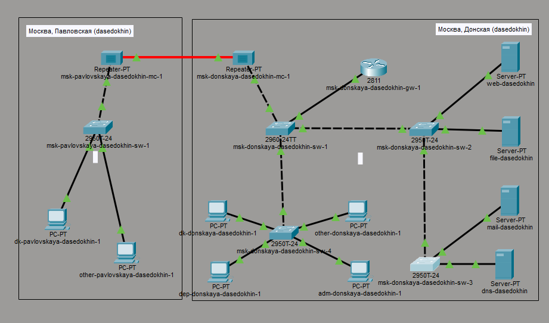

Рисунок 1: Размещение сервера dns и подключение его к коммутатору msk-donskaya-dasedokhin-sw-3

Активируем порт при помощи соответствующих команд на коммутаторе. (рис. 2).

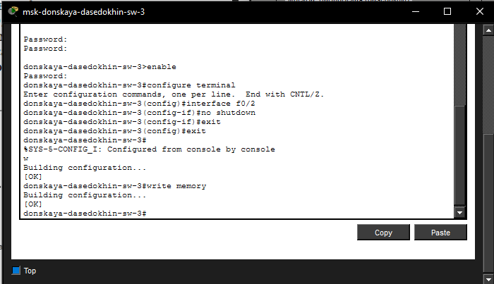

Рисунок 2: Активация порта на коммутаторе msk-donskaya-dasedokhin-sw-3

В конфигурации сервера укажите в качестве адреса шлюза 10.128.0.1, а в качестве адреса самого сервера — 10.128.0.5 с соответствующей маской 255.255.255.0. (рис. 3).

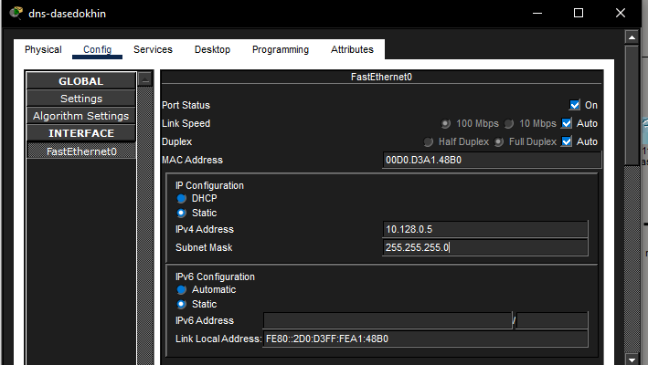

Рисунок 3: Назначение ip адреса и маски подсети для сервера

Настройте сервис DNS:

– в конфигурации сервера выберите службу DNS, активируйте её (выбрав флаг On);

– в поле Type в качестве типа записи DNS выберите записи типа A (A Record);

– в поле Name укажите доменное имя, по которому можно обратиться, например, к web-серверу — www.donskaya.rudn.ru, затем укажите его IP-адрес в соответствующем поле 10.128.0.2;

– нажав на кнопку Add , добавьте DNS-запись на сервер;

– сохраните конфигурацию сервера. (рис. 4).

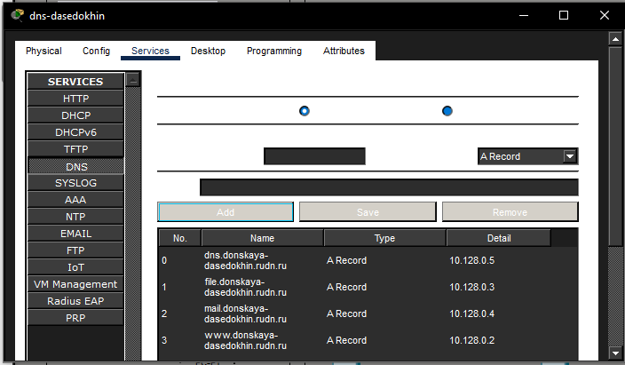

Рисунок 4: Настройка сервиса DNS

Настройте DHCP-сервис на маршрутизаторе, используя приведённые ниже команды для каждой выделенной сети: укажите IP-адрес DNS-сервера;

– Настройка DHCP:

msk−donskaya −gw−1>enable

msk−donskaya −gw −1#configure terminal

msk−donskaya −gw −1(config)#ip name −server 10.128.0.5

msk−donskaya −gw −1(config)#service dhcp

msk−donskaya −gw −1(config)#ip dhcp pool dk

msk−donskaya −gw −1(dhcp −config)#network 10.128.3.0 255.255.255.0

msk−donskaya −gw −1(dhcp −config)#default −router 10.128.3.1

msk−donskaya −gw −1(dhcp −config)#dns−server 10.128.0.5

msk−donskaya −gw −1(dhcp −config)#exit

msk−donskaya −gw −1(config)#ip dhcp excluded −address 10.128.3.1 10.128.3.29

msk−donskaya −gw −1(config)#ip dhcp excluded −address 10.128.3.200 10.128.3.254

msk−donskaya −gw −1(config)#ip dhcp pool departments

msk−donskaya −gw −1(dhcp −config)#network 10.128.4.0 255.255.255.0

msk−donskaya −gw −1(dhcp −config)#default −router 10.128.4.1

msk−donskaya −gw −1(dhcp −config)#dns−server 10.128.0.5

msk−donskaya −gw −1(dhcp −config)#exit

msk−donskaya −gw −1(config)#ip dhcp excluded −address 10.128.4.1 10.128.4.29

msk−donskaya −gw −1(config)#ip dhcp excluded −address 10.128.4.200 10.128.4.254

msk−donskaya −gw −1(config)#ip dhcp pool adm

msk−donskaya −gw −1(dhcp −config)#network 10.128.5.0 255.255.255.0

msk−donskaya −gw −1(dhcp −config)#default −router 10.128.5.1

msk−donskaya −gw −1(dhcp −config)#dns−server 10.128.0.5

msk−donskaya −gw −1(dhcp −config)#exit

msk−donskaya −gw −1(config)#ip dhcp excluded −address 10.128.5.1 10.128.5.29

msk−donskaya −gw −1(config)#ip dhcp excluded −address 10.128.5.200 10.128.5.254

msk−donskaya −gw −1(config)#ip dhcp pool other

msk−donskaya −gw −1(dhcp −config)#network 10.128.6.0 255.255.255.0

msk−donskaya −gw −1(dhcp −config)#default −router 10.128.6.1

msk−donskaya −gw −1(dhcp −config)#dns−server 10.128.0.5

msk−donskaya −gw −1(dhcp −config)#exit

msk−donskaya −gw −1(config)#ip dhcp excluded −address 10.128.6.1 10.128.6.29

msk−donskaya −gw −1(config)#ip dhcp excluded −address 10.128.6.200 10.128.6.254 (рис. 5).

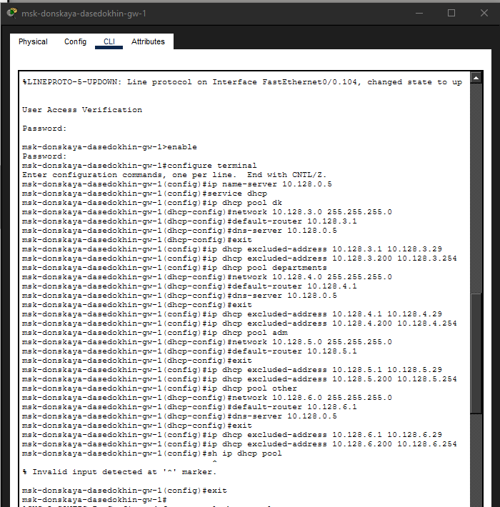

Рисунок 5: Настройка DHCP

– Информация о пулах DHCP:

msk−donskaya −gw −1#sh ip dhcp pool

– Информация об привязках выданных адресов:

msk−donskaya −gw −1#sh ip dhcp binding (рис. 6).

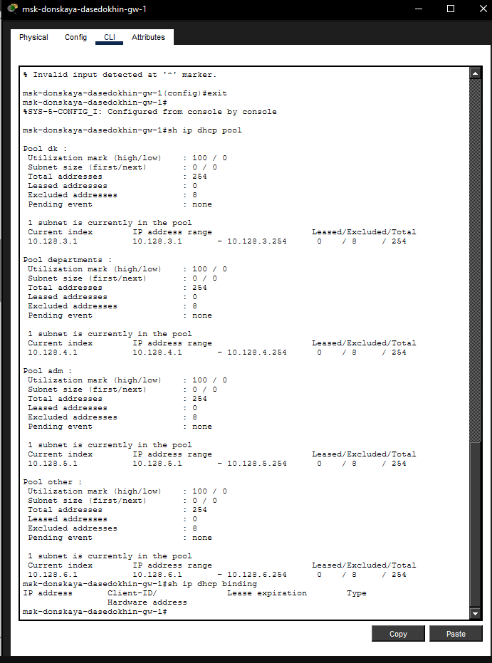

Рисунок 6: Информация о пулах DHCP и о привязках выданных адресов

На оконечных устройствах замените в настройках статическое распределение адресов на динамическое. (рис. 7).

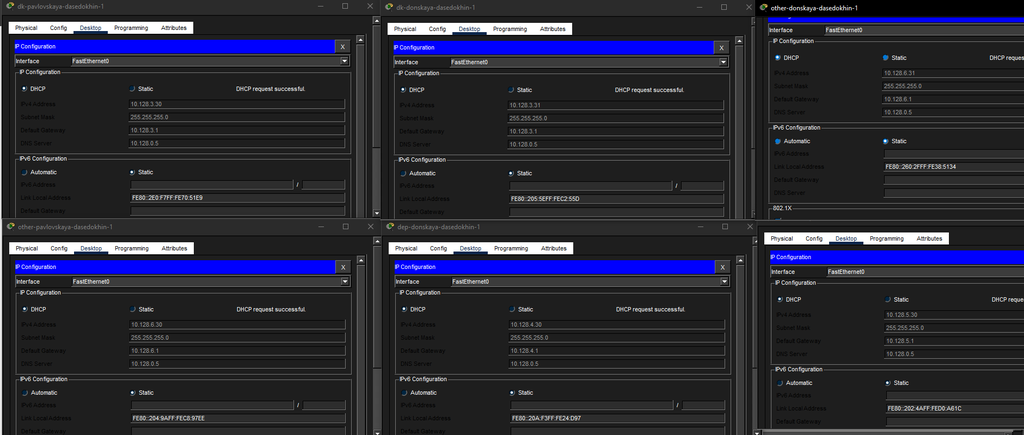

Рисунок 7: Замена на оконечных устройствах статическое расперделение адресов на динамическое

Проверьте, какие адреса выделяются оконечным устройствам, а также доступность устройств из разных подсетей. (рис. 8).

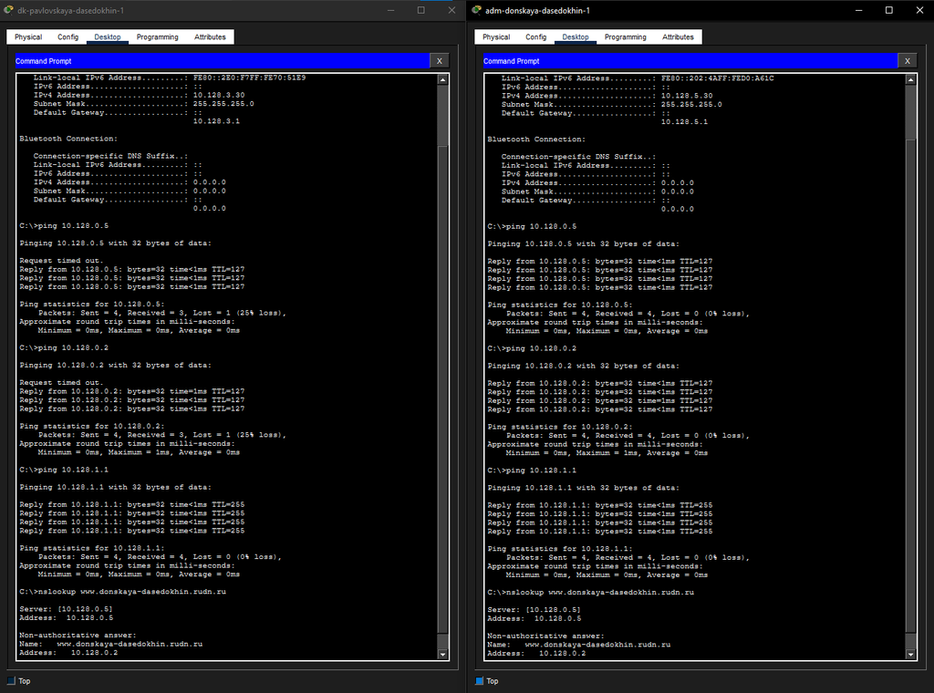

Рисунок 8: Проверка выделенных адресов оконечным устройствам и доступность устройств из разных подсетей

В режиме симуляции изучите, каким образом происходит запрос адреса по протоколу DHCP (какие сообщения и какие отклики передаются по сети). (рис. 9).

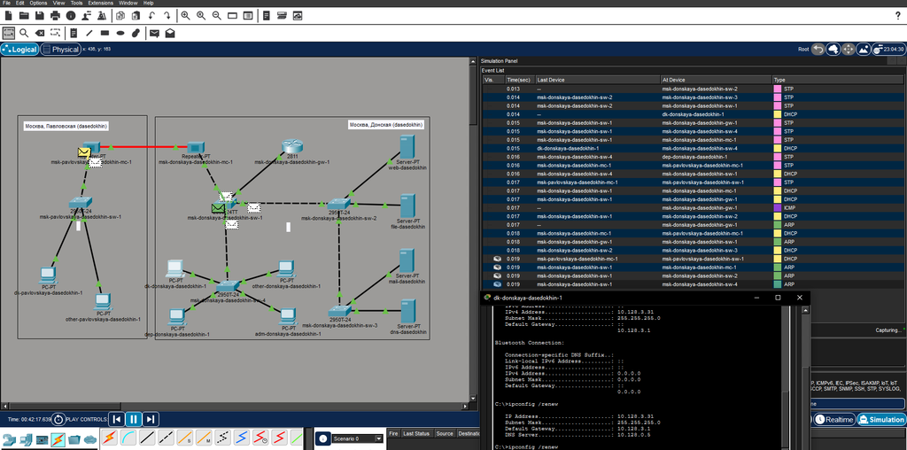

Рисунок 9: Изучение процесса запроса адреса по протоколу DHCP

# 3 Контрольные вопросы

1. Протокол DHCP (Dynamic Host Configuration Protocol) отвечает за автоматическую выдачу сетевым устройствам IP-адресов и других параметров, необходимых для работы в сети (маски подсети, шлюза по умолчанию, адресов DNS-серверов и т.д.), что избавляет от необходимости настраивать каждое устройство вручную.
2. Типы DHCP-сообщений: DHCPDISCOVER (поиск сервера), DHCPOFFER (предложение адреса), DHCPREQUEST (запрос адреса или продление аренды), DHCPACK (подтверждение выдачи), DHCPNAK (отказ в выдаче), DHCPDECLINE (отказ клиента от адреса из-за конфликта), DHCPRELEASE (освобождение адреса), DHCPINFORM (запрос дополнительных параметров при уже имеющемся IP).
3. В сообщениях DHCP могут передаваться: IP-адрес, маска подсети, адрес шлюза по умолчанию, адреса DNS-серверов, адреса WINS-серверов, доменное имя, NTP-сервер времени, параметры маршрутизации, MTU, время аренды адреса и другие опции, определяемые стандартом.
4. DNS (Domain Name System) — это распределенная система, которая преобразует понятные человеку доменные имена (например, yandex.ru) в числовые IP-адреса, необходимые для маршрутизации пакетов в сети, а также выполняет обратное преобразование.
5. Типы записей DNS:

A (Address) — сопоставляет доменное имя с IPv4-адресом.

AAAA — сопоставляет доменное имя с IPv6-адресом.

CNAME (Canonical Name) — создает псевдоним для другого имени (перенаправление).

MX (Mail Exchange) — указывает адрес почтового сервера для домена.

NS (Name Server) — указывает DNS-сервер, обслуживающий домен.

TXT — хранит произвольную текстовую информацию (например, SPF-записи для проверки почты).

PTR (Pointer) — обратная запись, преобразует IP-адрес в доменное имя.

SOA (Start of Authority) — содержит служебную информацию о зоне домена.

# 4 Выводы

Я приобрел практические наывки по настройке динамического распределения IP-адресов посредством протокола DHCP (Dynamic Host Configuration Protocol) в локальной сети.